# analises

Samuel Schmidt

## Análise de dados

Esse relatório tem como objetivo analisar dados da competição do Kaggle, buscando conhecer o comportamento do mercado.

### Devolução de produtos

Conforme o dicionário de dados da competição, dentro da base estão disponíveis as informações sobre a devolução de produtos (quantidade e valor de devolução). Sabe-se muito bem que a devolução acaba gerando custos desnecessários, pois muitas vezes dependendo da perecibilidade do produto, estes não podem ser reaproveitados, além também dos custos de logística.

Nos próximos gráficos serão analisados quantidade de devolução por semana, valor de devolução por semana, produtos mais devolvidos.

#### Quantidade Devolução por semana

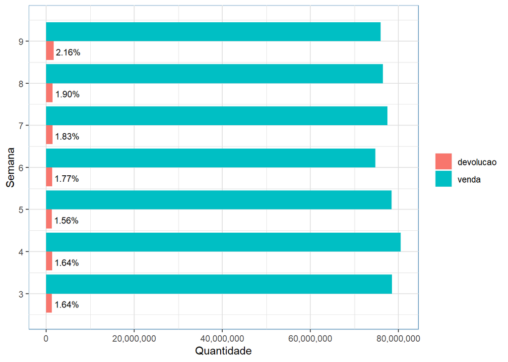

Conforme observado no gráfico acima, as devoluções tem representado entre 1,6% e 2.2% da quantidade dos itens vendidos.

#### Valor Devolução por semana

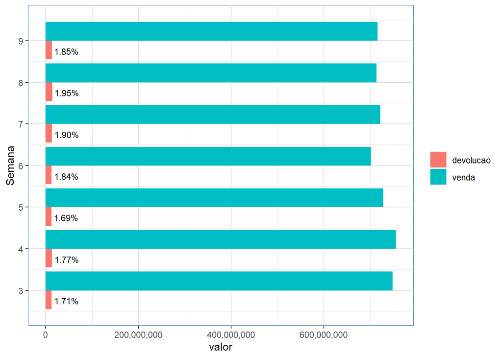

Conforme o gráfico acima demonstra, a devolução em valores, tem um percentual próximo a quantidade, sendo que se tratando de valores o intervalo de diferença entre o máximo e o mínimo é menor (1.7% a 2%).

#### Produtos mais devolvidos (quantidade abosoluta)

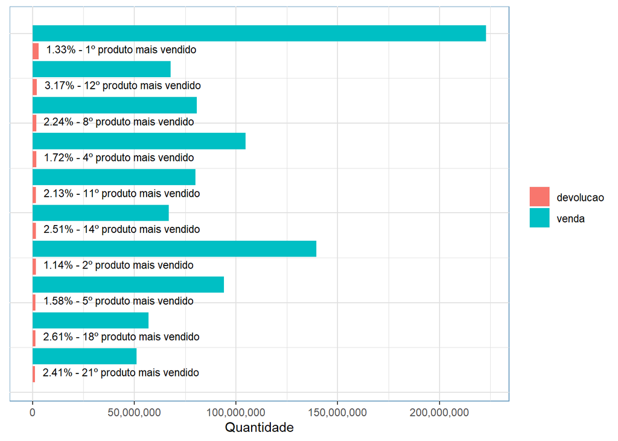

No gráfico pode-se observar que entre os 10 produtos que mais possuem unidades devolvidas, o produto mais vendido também está em primeiro lugar, porém esse produto possuí um percentual de devolução abaixo da grande maioria do produto nesse ranking, apenas o segundo produto mais vendido (7º mais devolvido) tem um percentual menor que o produto mais vendido.

#### Produtos mais devolvidos (percentual)

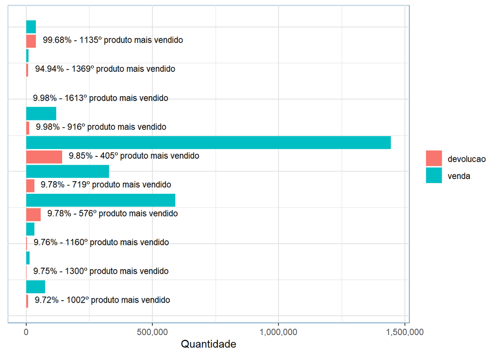

Com exceção dos produtos que ficaram nas duas primeiras posições, onde quase 100% do volume vendido foi devolvido, nos demais produtos o percentual de devolução ficou próximo a 10%, um índice bastante alto se comparado aos índices apresentados nos gráficos anteriores.

### Evolução nas vendas

Nos próximos gráficos serão explorados dados sumarizados sobre produtos que apresentaram evolução nas vendas semana após semana.

#### Produtos com evolução nas vendas por semana

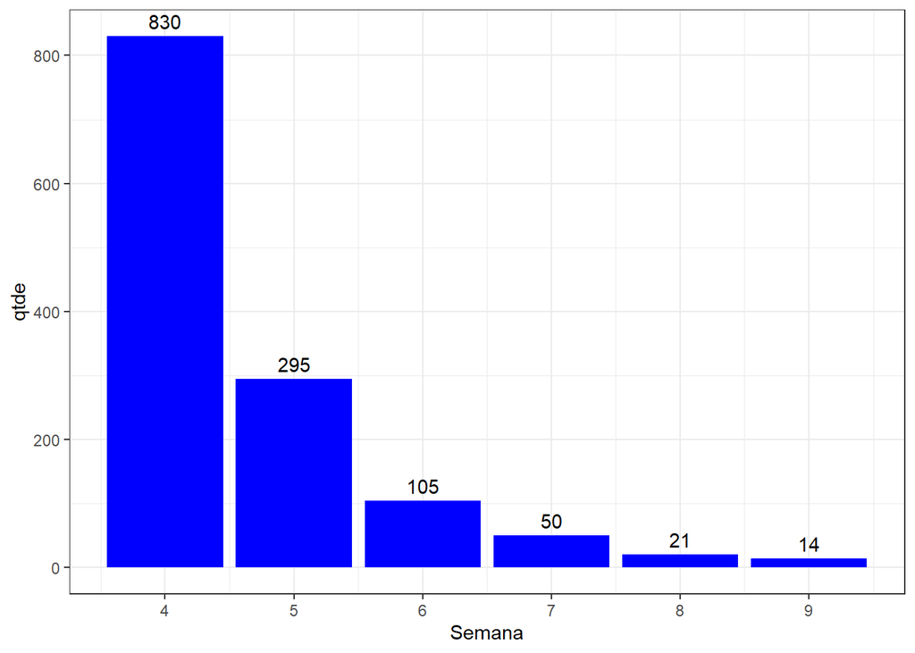

No gráfico acima pode-se observar que 830 produtos tiveram evolução nas vendas na semana 4 em relação a semana 3, desses 830, 295 tiveram novamente evolução na semana 5 com relação a semana 4, ao final das seis semanas, apenas 14 produtos apresentaram evolução nas vendas em todas as semanas.

#### Volumes de vendas por semana dos produtos que apresentaram evolução todas as semanas

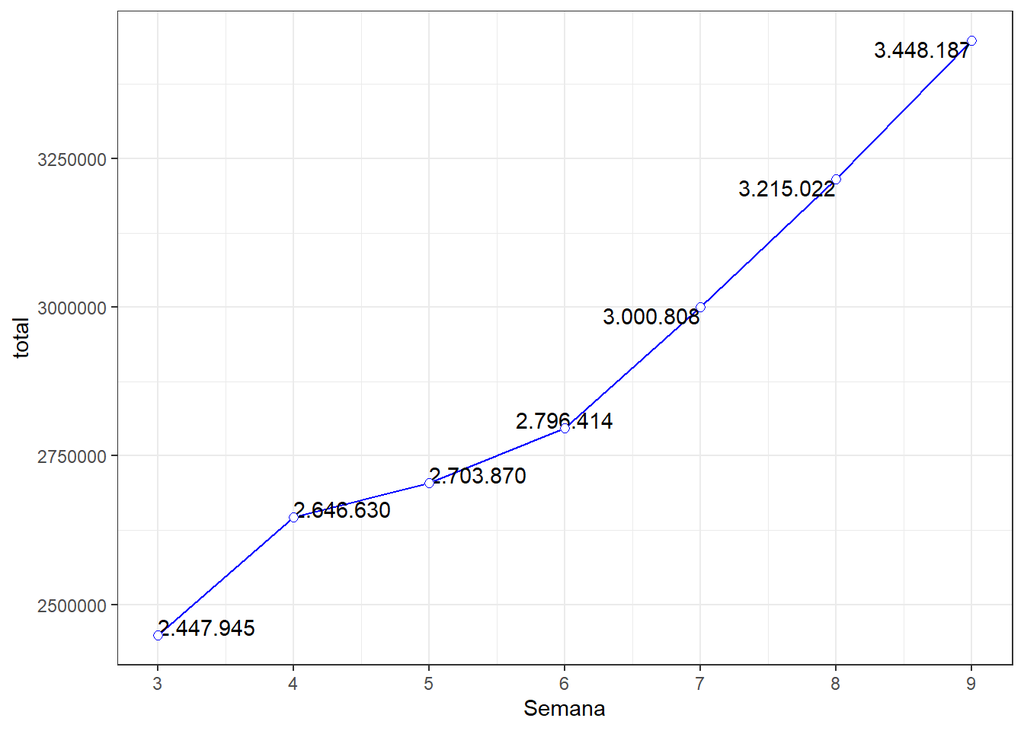

No gráfico acima pode-se observar a evolução ao longo das semanas nos 14 produtos que apresentaram evolução nas 6 semanas consecutivas, a quantidade total comercializada desses produtos na última semana foi 3.448.187 unidades, enquanto que o total na primeira semana foi de 2.447.945, ou seja, um incremento de 40.86% em 6 semanas.

#### Evolução volume de vendas geral

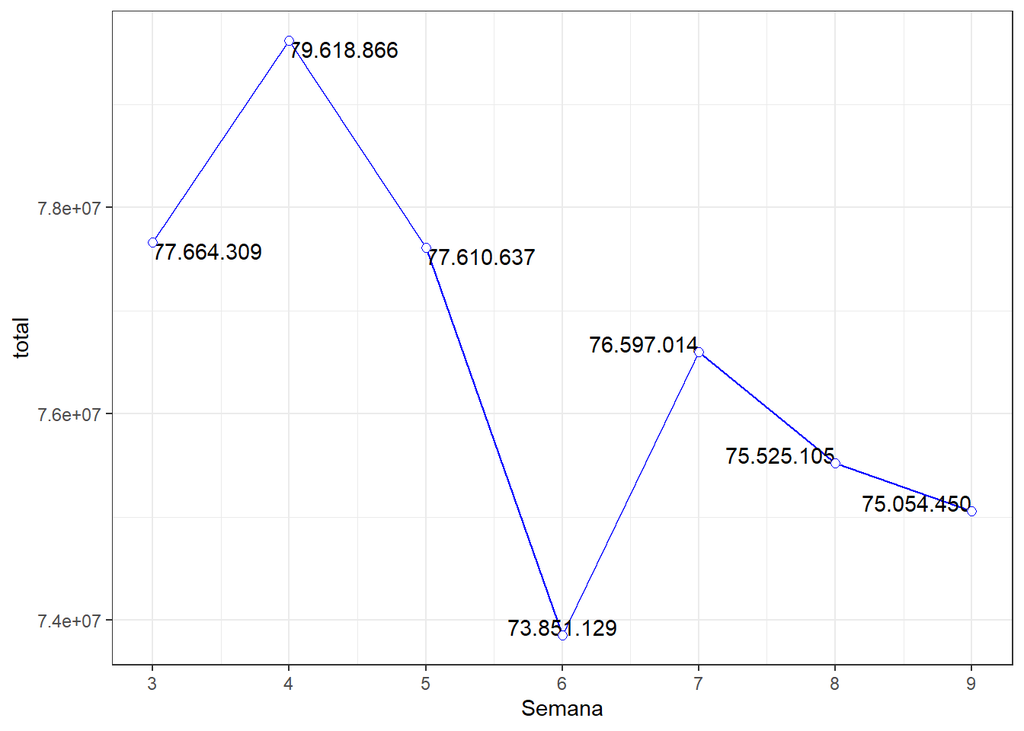

Analisando o volume de vendas geral, pode-se obsevar que não houve uma evolução constante, sendo que na última semana da base de dados, o volume de vendas foi 3,36% menor que na primeria semana.

#### Representatividade dos produtos nas vendas

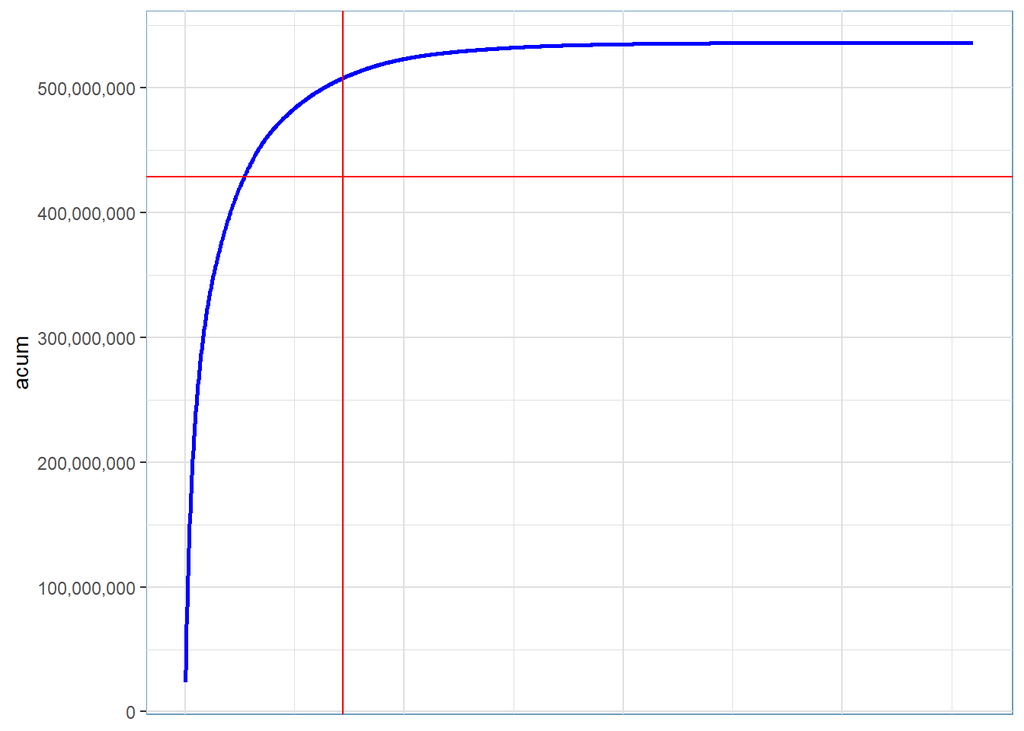

A linha azul do gráfico acima representa as vendas acumuladas por produto de forma descrescente, a linha vermelha horizontal representa 80% do total de produtos vendidos, a linha vermelha vertical representa os 20% produtos que mais venderam, ou seja, os 20% produtos que mais venderam, correspondem a mais de 80% das vendas, esse percentual foi de 94,7%.

#### Representatividade dos clientes nas vendas

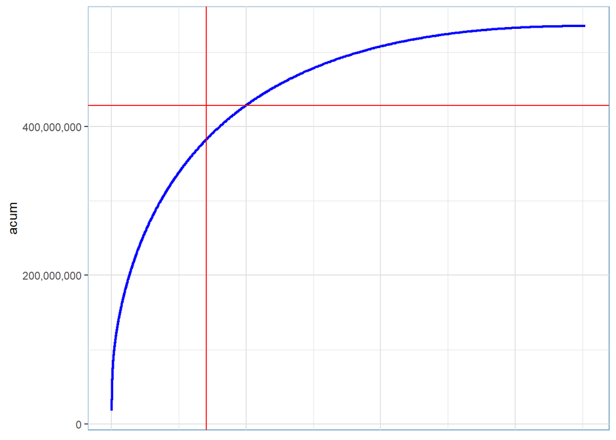

A linha azul do gráfico acima representa as vendas acumuladas por cliente de forma descrescente, a linha vermelha horizontal representa 80% do total de produtos vendidos, a linha vermelha vertical representa os 20% clientes que mais venderam, diferente do gráfico anterior, a linha azul cruza a linha dos 80% das vendas após cruzar linha dos 20% clientes que mais venderam. Os 20% clientes com maior volume de vendas, não chegaram vender 80% do total, esse percentual foi de 71,5%.

#### Vendas por estado

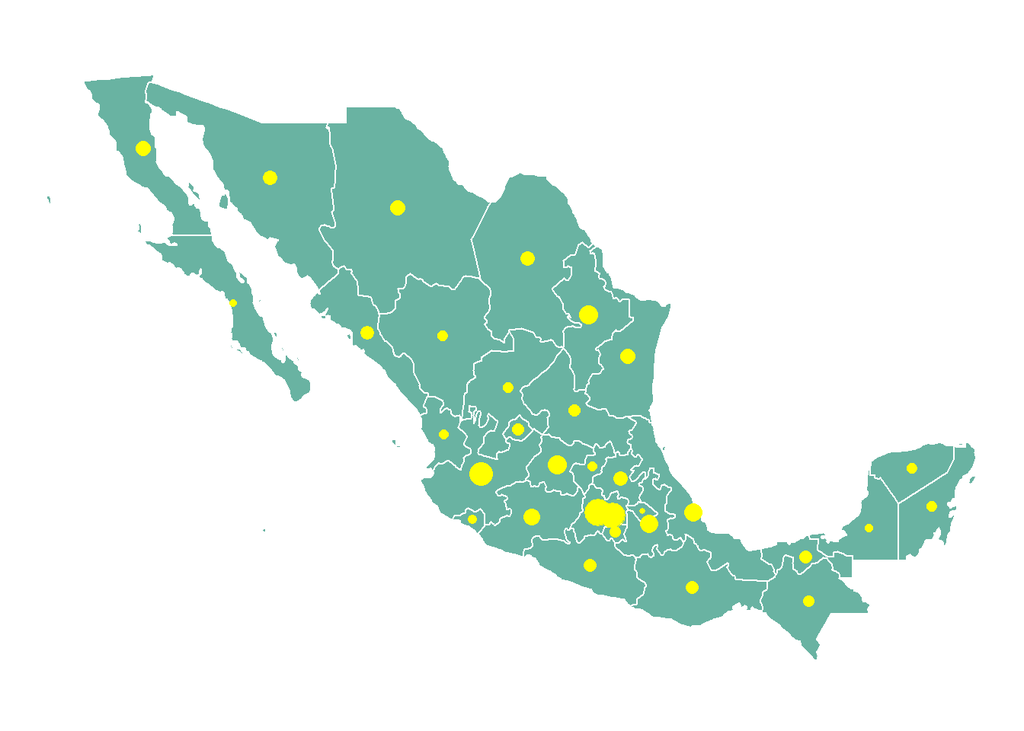

Conforme pode-se observar no mapa acima, as vendas tem um volume maior na região centro-sul do país, no geral, os volumes de vendas nos estados do norte apresenta-se acima da maioria dos estados.